# MachineLearningProject

E Robesyn

21 November 2015

```r
library(readr)
library(dplyr)
```

```r
library(ggplot2)
library(caret)
```

Read training and build prediction only with this dataset

Problems with read_csv from readr package: training<-read_csv(“./data/pml-training.csv”, na = c(“#DIV/0!”,“”,“NA”)) # cave: option is na (instead of na.strings for old read.csv function)

Problems(training): setting “#DIV/0!” as NA does not seem to work

Many variables still as char (while this is supposed not to happen with readr…)

Therefore old way of reading data

```r
setwd("C:/Users/Robesyn/Documents/5 DATA PROJECTS/CourseraMachineLearningProject")
training<-read.csv("./data/pml-training.csv", na.strings  = c("#DIV/0!","","NA"), stringsAsFactors = F)
training<-tbl_df(training)

dim(training)
```

```
## [1] 19622   160
```

```r
glimpse(training)  # last var "classe" is outcome to predict
```

```
## Observations: 19,622
## Variables: 160
## $ X                        (int) 1, 2, 3, 4, 5, 6, 7, 8, 9, 10, 11, 12...
## $ user_name                (chr) "carlitos", "carlitos", "carlitos", "...
## $ raw_timestamp_part_1     (int) 1323084231, 1323084231, 1323084231, 1...
## $ raw_timestamp_part_2     (int) 788290, 808298, 820366, 120339, 19632...
## $ cvtd_timestamp           (chr) "05/12/2011 11:23", "05/12/2011 11:23...
## $ new_window               (chr) "no", "no", "no", "no", "no", "no", "...
## $ num_window               (int) 11, 11, 11, 12, 12, 12, 12, 12, 12, 1...
## $ roll_belt                (dbl) 1.41, 1.41, 1.42, 1.48, 1.48, 1.45, 1...
## $ pitch_belt               (dbl) 8.07, 8.07, 8.07, 8.05, 8.07, 8.06, 8...
## $ yaw_belt                 (dbl) -94.4, -94.4, -94.4, -94.4, -94.4, -9...
## $ total_accel_belt         (int) 3, 3, 3, 3, 3, 3, 3, 3, 3, 3, 3, 3, 3...
## $ kurtosis_roll_belt       (dbl) NA, NA, NA, NA, NA, NA, NA, NA, NA, N...
## $ kurtosis_picth_belt      (dbl) NA, NA, NA, NA, NA, NA, NA, NA, NA, N...
```

[output cut: 147 more lines]

```r
#View(training)
```

Throw out character variables because prediction can only handle factors and if so, computationally heavy. Also, the char variables in this exercise do not matter for prediction. (cave discussion forum on the fact that this is time series data but not in the test set…, so not considering time windows here)

```r
training<-select(training, -c(1:7))
dim(training)
```

```
## [1] 19622   153
```

```r
summary(training)  # shows nr of NA per variable
```

```
##    roll_belt        pitch_belt          yaw_belt       total_accel_belt
##  Min.   :-28.90   Min.   :-55.8000   Min.   :-180.00   Min.   : 0.00
##  1st Qu.:  1.10   1st Qu.:  1.7600   1st Qu.: -88.30   1st Qu.: 3.00
##  Median :113.00   Median :  5.2800   Median : -13.00   Median :17.00
##  Mean   : 64.41   Mean   :  0.3053   Mean   : -11.21   Mean   :11.31
##  3rd Qu.:123.00   3rd Qu.: 14.9000   3rd Qu.:  12.90   3rd Qu.:18.00
##  Max.   :162.00   Max.   : 60.3000   Max.   : 179.00   Max.   :29.00
##
##  kurtosis_roll_belt kurtosis_picth_belt kurtosis_yaw_belt
##  Min.   :-2.121     Min.   :-2.190      Mode:logical
##  1st Qu.:-1.329     1st Qu.:-1.107      NA's:19622
##  Median :-0.899     Median :-0.151
##  Mean   :-0.220     Mean   : 4.334
##  3rd Qu.:-0.219     3rd Qu.: 3.178
##  Max.   :33.000     Max.   :58.000
##  NA's   :19226      NA's   :19248
##  skewness_roll_belt skewness_roll_belt.1 skewness_yaw_belt
##  Min.   :-5.745     Min.   :-7.616       Mode:logical
##  1st Qu.:-0.444     1st Qu.:-1.114       NA's:19622
##  Median : 0.000     Median :-0.068
##  Mean   :-0.026     Mean   :-0.296
##  3rd Qu.: 0.417     3rd Qu.: 0.661
##  Max.   : 3.595     Max.   : 7.348
##  NA's   :19225      NA's   :19248
##  max_roll_belt     max_picth_belt   max_yaw_belt   min_roll_belt
##  Min.   :-94.300   Min.   : 3.00   Min.   :-2.10   Min.   :-180.00
##  1st Qu.:-88.000   1st Qu.: 5.00   1st Qu.:-1.30   1st Qu.: -88.40
##  Median : -5.100   Median :18.00   Median :-0.90   Median :  -7.85
##  Mean   : -6.667   Mean   :12.92   Mean   :-0.22   Mean   : -10.44
##  3rd Qu.: 18.500   3rd Qu.:19.00   3rd Qu.:-0.20   3rd Qu.:   9.05
##  Max.   :180.000   Max.   :30.00   Max.   :33.00   Max.   : 173.00
##  NA's   :19216     NA's   :19216   NA's   :19226   NA's   :19216
##  min_pitch_belt   min_yaw_belt   amplitude_roll_belt amplitude_pitch_belt
##  Min.   : 0.00   Min.   :-2.10   Min.   :  0.000     Min.   : 0.000
##  1st Qu.: 3.00   1st Qu.:-1.30   1st Qu.:  0.300     1st Qu.: 1.000
##  Median :16.00   Median :-0.90   Median :  1.000     Median : 1.000
##  Mean   :10.76   Mean   :-0.22   Mean   :  3.769     Mean   : 2.167
##  3rd Qu.:17.00   3rd Qu.:-0.20   3rd Qu.:  2.083     3rd Qu.: 2.000
##  Max.   :23.00   Max.   :33.00   Max.   :360.000     Max.   :12.000
##  NA's   :19216   NA's   :19226   NA's   :19216       NA's   :19216
```

[output cut: 297 more lines]

```
##  Min.   : -8.0900   Min.   :-498.00   Min.   :-632.0   Min.   :-446.00
##  1st Qu.: -0.1800   1st Qu.:-178.00   1st Qu.:  57.0   1st Qu.:-182.00
##  Median :  0.0800   Median : -57.00   Median : 201.0   Median : -39.00
##  Mean   :  0.1512   Mean   : -61.65   Mean   : 163.7   Mean   : -55.29
##  3rd Qu.:  0.4900   3rd Qu.:  76.00   3rd Qu.: 312.0   3rd Qu.:  26.00
##  Max.   :231.0000   Max.   : 477.00   Max.   : 923.0   Max.   : 291.00
##
##  magnet_forearm_x  magnet_forearm_y magnet_forearm_z    classe
##  Min.   :-1280.0   Min.   :-896.0   Min.   :-973.0   Length:19622
##  1st Qu.: -616.0   1st Qu.:   2.0   1st Qu.: 191.0   Class :character
##  Median : -378.0   Median : 591.0   Median : 511.0   Mode  :character
##  Mean   : -312.6   Mean   : 380.1   Mean   : 393.6
##  3rd Qu.:  -73.0   3rd Qu.: 737.0   3rd Qu.: 653.0
##  Max.   :  672.0   Max.   :1480.0   Max.   :1090.0
##
```

Given that some variables have many na’s, complete cases is bad choice because this throws out rows. Illustration:

dim(training) training_clean <- training[complete.cases(training),] dim(training_clean)

Instead select var out with many na

```r
training <- training[, colMeans(is.na(training)) <= .15]
training <- training[, colMeans(is.na(training)) <= .01]  # does not change (remains 53 var)
training <- training[, colMeans(is.na(training)) <= 0]    # does not change (remains 53 var)

dim(training)  # down from 153 var to 53 var # keep only var with less then 15% missing (the remaining I can try to impute but beware that increases uncertainty)
```

```
## [1] 19622    53
```

```r
summary(training)  # indeed, none of the var has NA anymore
```

```
##    roll_belt        pitch_belt          yaw_belt       total_accel_belt
##  Min.   :-28.90   Min.   :-55.8000   Min.   :-180.00   Min.   : 0.00
##  1st Qu.:  1.10   1st Qu.:  1.7600   1st Qu.: -88.30   1st Qu.: 3.00
##  Median :113.00   Median :  5.2800   Median : -13.00   Median :17.00
##  Mean   : 64.41   Mean   :  0.3053   Mean   : -11.21   Mean   :11.31
##  3rd Qu.:123.00   3rd Qu.: 14.9000   3rd Qu.:  12.90   3rd Qu.:18.00
##  Max.   :162.00   Max.   : 60.3000   Max.   : 179.00   Max.   :29.00
##   gyros_belt_x        gyros_belt_y       gyros_belt_z
##  Min.   :-1.040000   Min.   :-0.64000   Min.   :-1.4600
##  1st Qu.:-0.030000   1st Qu.: 0.00000   1st Qu.:-0.2000
##  Median : 0.030000   Median : 0.02000   Median :-0.1000
##  Mean   :-0.005592   Mean   : 0.03959   Mean   :-0.1305
##  3rd Qu.: 0.110000   3rd Qu.: 0.11000   3rd Qu.:-0.0200
##  Max.   : 2.220000   Max.   : 0.64000   Max.   : 1.6200
##   accel_belt_x       accel_belt_y     accel_belt_z     magnet_belt_x
##  Min.   :-120.000   Min.   :-69.00   Min.   :-275.00   Min.   :-52.0
##  1st Qu.: -21.000   1st Qu.:  3.00   1st Qu.:-162.00   1st Qu.:  9.0
##  Median : -15.000   Median : 35.00   Median :-152.00   Median : 35.0
##  Mean   :  -5.595   Mean   : 30.15   Mean   : -72.59   Mean   : 55.6
##  3rd Qu.:  -5.000   3rd Qu.: 61.00   3rd Qu.:  27.00   3rd Qu.: 59.0
##  Max.   :  85.000   Max.   :164.00   Max.   : 105.00   Max.   :485.0
##  magnet_belt_y   magnet_belt_z       roll_arm         pitch_arm
##  Min.   :354.0   Min.   :-623.0   Min.   :-180.00   Min.   :-88.800
##  1st Qu.:581.0   1st Qu.:-375.0   1st Qu.: -31.77   1st Qu.:-25.900
##  Median :601.0   Median :-320.0   Median :   0.00   Median :  0.000
##  Mean   :593.7   Mean   :-345.5   Mean   :  17.83   Mean   : -4.612
##  3rd Qu.:610.0   3rd Qu.:-306.0   3rd Qu.:  77.30   3rd Qu.: 11.200
##  Max.   :673.0   Max.   : 293.0   Max.   : 180.00   Max.   : 88.500
##     yaw_arm          total_accel_arm  gyros_arm_x        gyros_arm_y
##  Min.   :-180.0000   Min.   : 1.00   Min.   :-6.37000   Min.   :-3.4400
##  1st Qu.: -43.1000   1st Qu.:17.00   1st Qu.:-1.33000   1st Qu.:-0.8000
##  Median :   0.0000   Median :27.00   Median : 0.08000   Median :-0.2400
##  Mean   :  -0.6188   Mean   :25.51   Mean   : 0.04277   Mean   :-0.2571
##  3rd Qu.:  45.8750   3rd Qu.:33.00   3rd Qu.: 1.57000   3rd Qu.: 0.1400
##  Max.   : 180.0000   Max.   :66.00   Max.   : 4.87000   Max.   : 2.8400
##   gyros_arm_z       accel_arm_x       accel_arm_y      accel_arm_z
##  Min.   :-2.3300   Min.   :-404.00   Min.   :-318.0   Min.   :-636.00
##  1st Qu.:-0.0700   1st Qu.:-242.00   1st Qu.: -54.0   1st Qu.:-143.00
##  Median : 0.2300   Median : -44.00   Median :  14.0   Median : -47.00
##  Mean   : 0.2695   Mean   : -60.24   Mean   :  32.6   Mean   : -71.25
```

[output cut: 50 more lines]

```
##  Max.   :311.00000   Max.   :231.0000   Max.   : 477.00   Max.   : 923.0
##  accel_forearm_z   magnet_forearm_x  magnet_forearm_y magnet_forearm_z
##  Min.   :-446.00   Min.   :-1280.0   Min.   :-896.0   Min.   :-973.0
##  1st Qu.:-182.00   1st Qu.: -616.0   1st Qu.:   2.0   1st Qu.: 191.0
##  Median : -39.00   Median : -378.0   Median : 591.0   Median : 511.0
##  Mean   : -55.29   Mean   : -312.6   Mean   : 380.1   Mean   : 393.6
##  3rd Qu.:  26.00   3rd Qu.:  -73.0   3rd Qu.: 737.0   3rd Qu.: 653.0
##  Max.   : 291.00   Max.   :  672.0   Max.   :1480.0   Max.   :1090.0
##     classe
##  Length:19622
##  Class :character
##  Mode  :character
##
##
##
```

pml-testing dataset already split off, however this is for the final test of 20 cases. There is still a need for createDataPartition() as I want to have a subset to estimate the out-of-sample error.

Outcome “classe”

```r
head(training$classe)
```

```
## [1] "A" "A" "A" "A" "A" "A"
```

```r
tail(training$classe)
```

```
## [1] "E" "E" "E" "E" "E" "E"
```

```r
str(training$classe) # character
```

```
##  chr [1:19622] "A" "A" "A" "A" "A" "A" "A" "A" "A" ...
```

```r
training$classe<-as.factor(training$classe)
str(training$classe) # factor
```

```
##  Factor w/ 5 levels "A","B","C","D",..: 1 1 1 1 1 1 1 1 1 1 ...
```

```r
levels(training$classe)
```

```
## [1] "A" "B" "C" "D" "E"
```

```r
table(training$classe)
```

```
##
##    A    B    C    D    E
## 5580 3797 3422 3216 3607
```

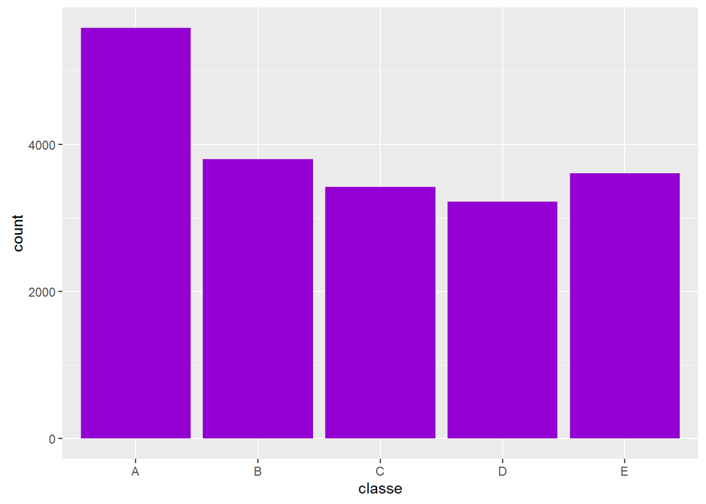

```r
ggplot(data=training, aes(classe))+geom_bar(fill="darkviolet")
```

Datapartition of training dataset

```r
inTrain<-createDataPartition(y=training$classe, p=0.70, list=F) # cave use . instead of ,
trainingtrain<-training[inTrain,] # to build model
trainingtest<-training[-inTrain,] # to estimate out of sample error (while still building model)

dim(trainingtrain)
```

```
## [1] 13737    53
```

```r
dim(trainingtest)
```

```
## [1] 5885   53
```

from here on I build model only with trainingtrain - at the end I estimate out of sample error with trainingtest and conclude with that in my report.